```r
library(tidyverse)
library(IRdisplay)
```

# Histograms

We can plot a histogram if we only care about the distribution of one variable

1. What are the smallest and largest values?
2. What is the "center" or "most typical" value?
3. How do the values spread out?
4. What are the frequent and infrequent values?

A histogram is a plot that visualizes the distribution of a numerical value as follows:

1. We first cut up the x-axis into a series of bins, where each bin represents a range of values.
2. For each bin, we count the number of observations that fall in the range corresponding to that bin.
3. Then for each bin, we draw a bar whose height marks the corresponding count.

## geom_histogram()

```
ggplot(mpg) +
    geom_histogram(mapping = aes(x = hwy))
```

Unlike scatterplots and linegraphs, there is now only one variable being mapped in aes(): the numerical variable hwy

The y-aesthetic of a histogram, the count of the observations in each bin, gets computed automatically.

Question: what is the requirement for the type of variable in x?

It is hard to distinguish each bin.

# `geom_hitogram()`

We can use color argument to add borders.

```
ggplot(mpg) +
    geom_histogram(mapping = aes(x = hwy), color="white")
```

You can use the fill argument to change the color of the bars

```
ggplot(mpg) +
    geom_histogram(mapping = aes(x = hwy), color = "white", fill = "steelblue")
```

If you're curious, run colors() to see all possible choices of colors in R.

## Adjusting the bins

### Adjusting number of bins

We can use the bins argument specify how many bins we would like to cut the x-axis up in.

```
{r}
ggplot(mpg)+
  geom_histogram(mapping = aes(x=hwy),color="white",bins=40)
```

### Adjusting the bin width

We can use the binwidth argument to specify the width of the bins.

```
{r}
ggplot(mpg)+
  geom_histogram(mapping = aes(x=hwy),color="white",binwidth=1)
```

### Setting the boundaries manually

We can use the `breaks` argument to specify the boundaries of the bins.

```
ggplot(mpg)+
  geom_histogram(mapping = aes(x=hwy),color="white",breaks=10:45)
```

# The shape of the distribution

- Determining the shape of your variable is essential before any further analysis is done.
- Statistical methods used for inference often require your data to be distibuted in a certain manner before they can be applied to the data.
- You can describe the shape in terms of:
  - Is it symmetric?
  - How many peaks does it have?
  - Is it skewed to the left or right?
  - Is it close to uniform?

## The Normal Distribution

- Also referred to as the Gaussian distribution
- Very common distribution and is often described as a bell-shaped curve
- Often described as a bell-shaped curve.
- Values are symmetric around the central value
- High density of the values falling right around the central value

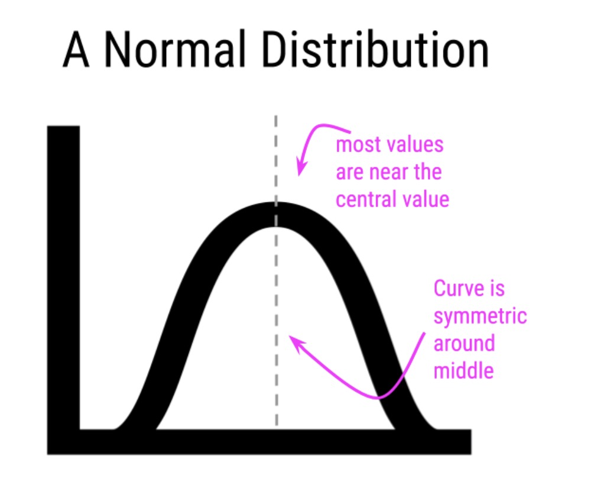

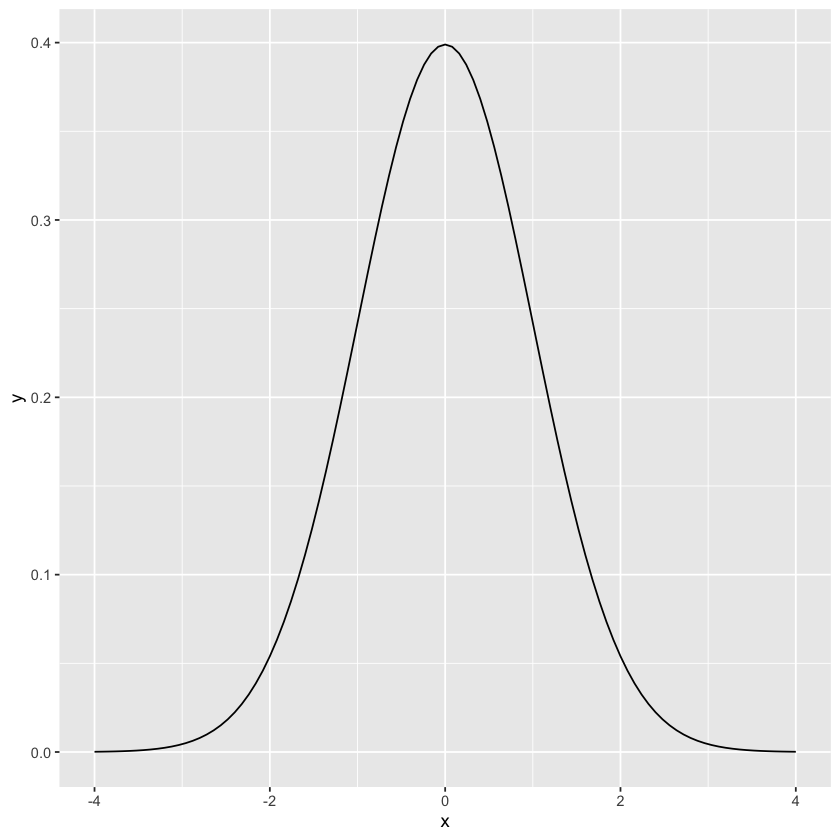

```r
ggplot(data.frame(x = c(-4, 4)), aes(x = x)) +
stat_function(fun = dnorm)
```

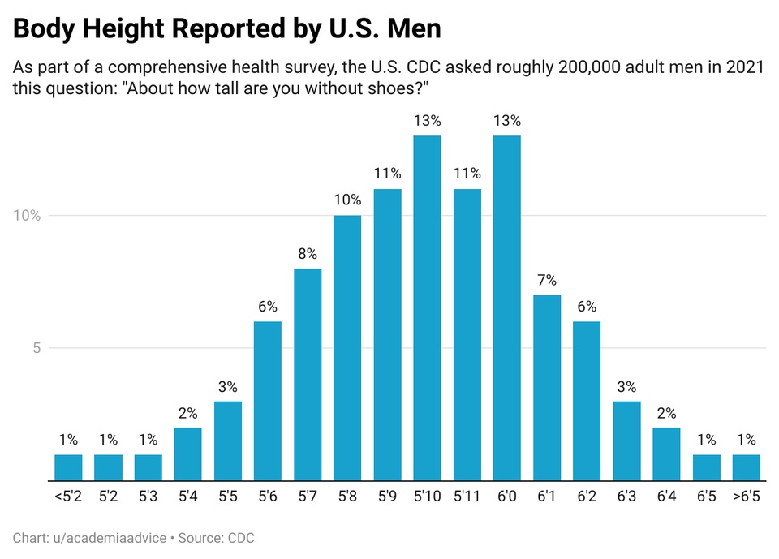

## A variable can be described as normally distributed if:

- There is a strong tendency for data to take a central value
- Deviations away from the central value are equally likely in both directions

# Skewed distribution

Most of the values fall to one end of the range, leaving a tail off to the other side.

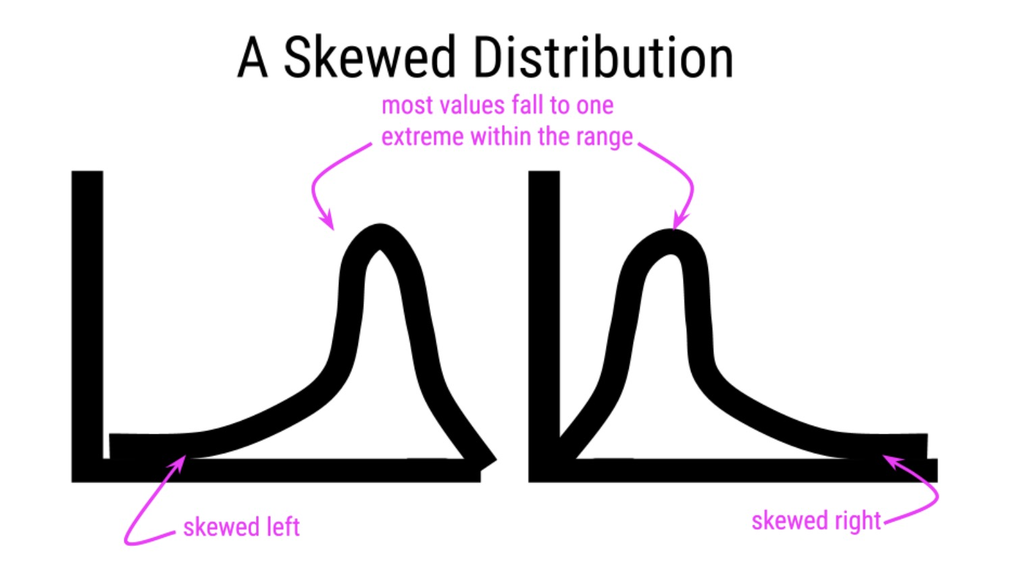

**Uniform Distribution**: Values for a variable are equally likely along any portion of the distribution.

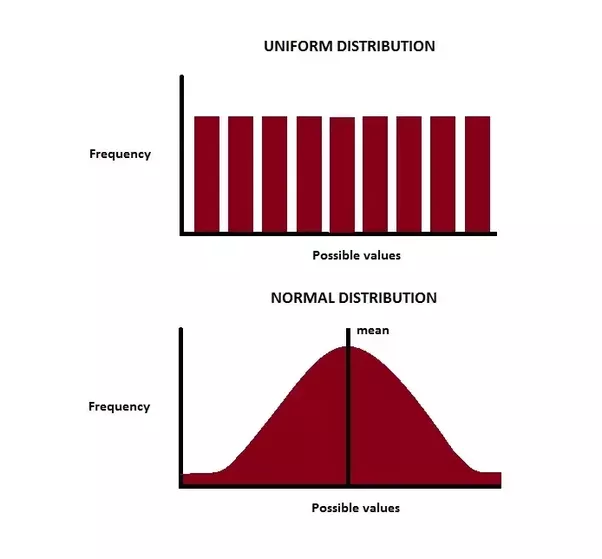

# Your turn

- Create histograms for `cty` and `displ` respectively. Describe how the variables are distributed.

# `geom_freqpoly()`

`geom_freqpoly()` displays the counts with lines instead of bars.

```
ggplot(mpg)+
  geom_freqpoly(mapping = aes(x=hwy))

ggplot(mpg)+
  geom_freqpoly(mapping = aes(x=hwy,color=drv))
```

# Boxplots

### `geom_boxplot()`

What if we want to compare the distribution of a numerical variable split by the values of another variable?

- Suppose we want to compare the distribution of `hwy` for each value of `drv`.
- We can use freqpoly or faceted histograms

```
ggplot(mpg)+
  geom_freqpoly(mapping = aes(x=hwy,color = drv))

ggplot(mpg)+
  geom_histogram(mapping = aes(x=hwy),color="white")+
      facet_wrap(~drv)
```

Another type of visualization that achieves this same goal is a side-by-side boxplot.

- It compactly displays the distribution of a numerical variable by visualizing several **summary statistics** (minimum, maximum, median, quartiles)

```
ggplot(mpg)+
  geom_boxplot(mapping = aes(y=hwy))
```

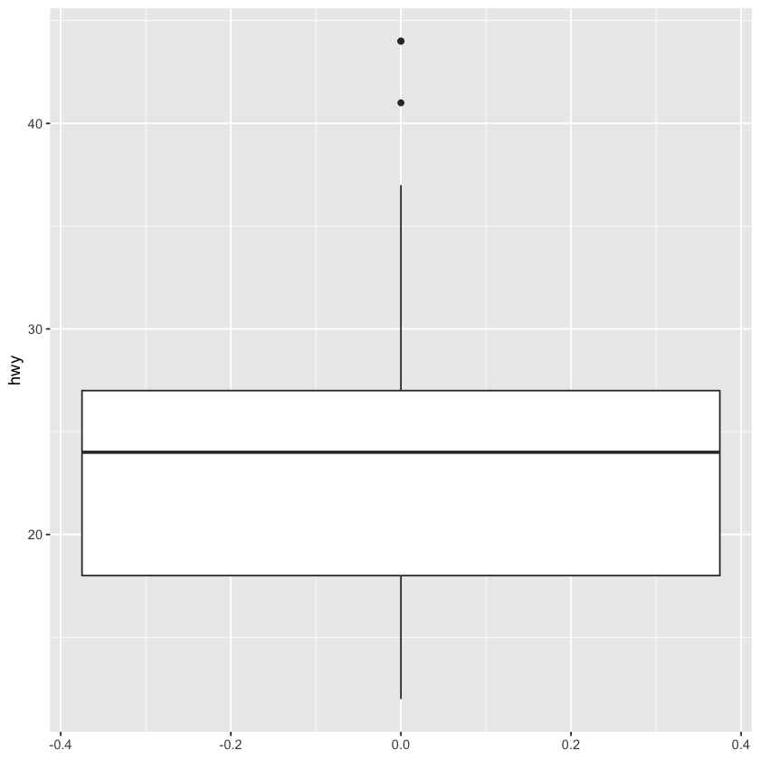

```r
ggplot(mpg)+
  geom_boxplot(mapping = aes(y=hwy))
```

## Boxplot

Summarizes the 234 points by cutting them into quartiles.

- 25% of observations fall below the bottom edge of the box (< 18 mpg)
- 25% of observations fall between the bottom edge of the box (Lower Quartile = 18 mpg) and the middle line (median = 24 mpg)
- 25% of observations fall between the median and the top edge of the box (Upper Quartile = 27 mpg)
- 25% of observations fall above the upper quartile (> 27 mpg)

### What's in the box?!

- The middle 50% of points fall within the interquartile range (IQR) between the Upper and Lower Quartiles. -The interquartile range for `hwy` is IQR = UQ - LQ = 27 - 18 = 9
- The interquartile range is a measure of a numerical variable's spread.

### Side by side boxplot

We can create a side-by-side boxplot of hwy split by drv. We do this by mapping drv to the x-position aesthetic, hwy to the y-position aesthetic

```
ggplot(mpg)+
  geom_boxplot(mapping = aes(x=drv,y=hwy))
```

# Your turn

- Can the variable in the `x`-position be numerical?
- Create a boxplot of `hwy` split by `class`. Interpret your findings.

# Violin Plots

- A violin plot displays the distribution of a numerical variable.
- You can view it as a blend of boxplots and histograms.

```
ggplot(mpg)+
  geom_violin(mapping = aes(x=class,y=hwy))
```

# Bar plots

- Both histograms and boxplots are tools to visualize the distribution of numerical variables
- What about categorical variables?
  - Just count the observations in each category
  - A good representation of this is a bar plot

### `geom_bar()`

A bar chart or bar graph presents categorical data with bars with heights or lengths proportional to the value that they represent.

```
ggplot(mpg)+
 geom_bar(mapping = aes(x=drv))

ggplot(mpg)+
 geom_bar(mapping = aes(x=trans))
```

# Two categorical variables

- Another use of barplots is to visualize the joint distribution of two categorical variables at the same time.
- Suppose we want to know the distribution of `trans` split by `drv` We can now map the additional variable `drv` by adding a `fill = drv` inside the `aes()` aesthetic mapping.

```
ggplot(mpg)+
  geom_bar(mapping = aes(x=trans,fill = drv ))
```

- The fill argument controls the color of the bars, while the color argument controls the color of the outline of the bars.

```
ggplot(mpg)+
  geom_bar(mapping = aes(x=trans,color = drv ))
```

- It is difficult to compare the heights of the different colors between the bars. We can use the position adjustment (we will learn more about this later)

```
ggplot(mpg)+
  geom_bar(mapping = aes(x=trans,fill = drv ),position = "dodge")
```

# Summary

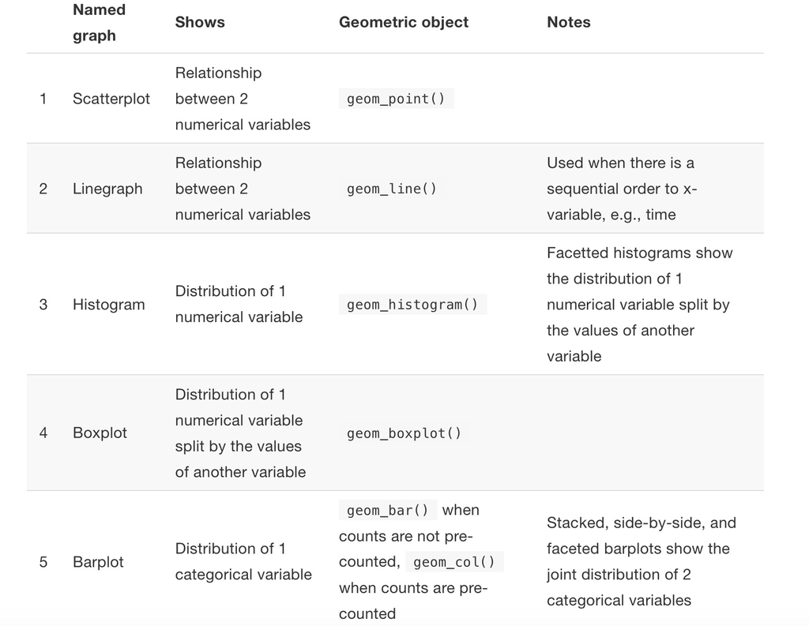

# Global mappings

To display multiple `geoms` in the same plot, add multiple geoms to `ggplot()`

```
ggplot(data = mpg) +
  geom_point(mapping = aes(x = displ, y = hwy)) +
  geom_smooth(mapping = aes(x = displ, y = hwy))
```

- This introduces some duplication in our code
- You can avoid this type of repetition by passing a set of mappings to `ggplot()`
- `ggplot2` will treat these mappings as global mappings that apply to each geom in the graph.

```
ggplot(data = mpg,mapping = aes(x = displ, y = hwy)) +
  geom_point() +
  geom_smooth()
```

- If you place mappings in the geom function, `ggplot2` will treat them as local mappings for the layer.
- It will use these mappings to extend or overwrite the global mappings for that layer only

```
ggplot(data = mpg, mapping = aes(x = displ, y = hwy)) +
  geom_point(mapping = aes(color = class)) +
  geom_smooth()
```

- You can use the same idea to specify different data for each layer.
- In the following code, the smooth line dispalys just a subset of the mpg dataset, the subcompact cars.
- The local data argument in `geom_smooth()` overrides the global data argument in `ggplot()` for that layer only.

```
ggplot(data = mpg, mapping = aes(x = displ, y = hwy)) +
  geom_point(mapping = aes(color = class)) +
  geom_smooth(data = filter(mpg, class == "subcompact"), se = FALSE)
```

# Your turn

1. Run this code in your head and predict what the output will look like.
2. Run the code in R and check your predictions

```
ggplot(data = mpg, mapping = aes(x = displ, y = hwy, color = drv)) +
  geom_point() +
  geom_smooth(se = FALSE)
```

3. Run the following codes and see what they do

```
ggplot(mpg, aes(x = displ, y = hwy)) +
  geom_point(aes(color = drv)) +
  geom_smooth(aes(linetype = drv), se = FALSE)

ggplot(mpg, aes(x = displ, y = hwy)) +
  geom_point(size = 4, color = "white") +
  geom_point(aes(color = drv))
```

4. Recreate the code necessary to generate the following graph

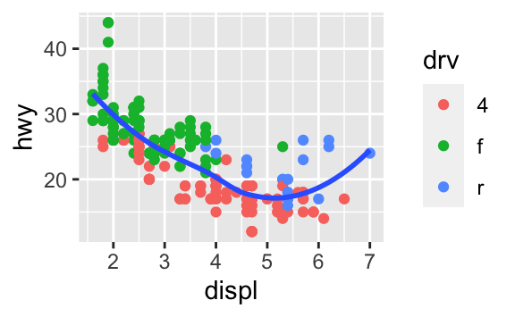